# Date-Time Howto

Jeff Newmiller

October 2, 2018

# Desirable features for handling date/times

- Convert to and from character (format/parse)
- Compare two dates (before, same time, or after?)
- Quantify interval between two moments in time
- Create periodic sequences of moments in time
- Handle calendar/time special cases

We will cover these topics “as-needed” by importing a couple of data files.

# Cleaned Residential Data

Sample residential electric load data from London, England[^1] (pre-trimmed to one house and odd records removed)

```r
dta <- read.csv( "../data/MAC000002clean.csv", as.is = TRUE )
str(dta)
```

```
## 'data.frame':    24158 obs. of  3 variables:
##  $ LCLid   : chr  "MAC000002" "MAC000002" "MAC000002" "MAC000002" ...
##  $ DateTime: chr  "2012-10-12 00:30:00.0000000" "2012-10-12 01:00:00.0000000" "2012-10-12 01:30:00.0000000" "2012-10-12 02:00:00.0000000" ...
##  $ KWH     : num  0 0 0 0 0 0 0 0 0 0 ...
```

# Base R Timestamp

Tell R to assume timezone is Greenwich Mean Time (or Universal Time Coordinated = UTC)

```r
Sys.setenv( TZ = "GMT" ) # when you don't know how the data was coded, use GMT
```

Make a `Dtm` column using base R. The “%Y-%m-%d %H:%M:%OS” format works by default, but many common formats need to be specified with a `format` argument (`?strptime`).

```r
dta_b <- dta  # make a copy so we can compare approaches later
dta_b$Dtm <- as.POSIXct( dta_b$DateTime ) # assumes TZ is set
str( dta_b$Dtm ) # confirming new column type
```

```
##  POSIXct[1:24158], format: "2012-10-12 00:30:00" "2012-10-12 01:00:00" ...
```

`POSIXct` is a time representation that borrows heavily from the *Portable Operating Systems Interface* (POSIX) standard, which uses integer values to indicate time as the number of seconds since January 1, 1970 Greenwich Mean Time. R uses a double-precision floating point number instead of an integer, but is otherwise very similar to the original standard.

# Aside: Timezones

Excel basically acts like all time is in GMT all the time… if you compute `'2012-03-26' - '2012-03-25'` in Excel you get 1 day (24 hours), even though in London, March 25, 2012 was the beginning of daylight savings time so the day was 23 hours long. For many uses this is fine, but R timestamps always keep timezones in mind so if you *want* to use simplified time in R like you can in Excel then you need to set the timezone to GMT before you do time calculations.

You can set a default timezone for time calculations in a particular R session in the manner of the previous page, or you can set an attribute `"tzone"` on each timezone variable. Timezones affect how the character strings are converted to POSIXct and back to character. It also affects how `POSIXct` <-> `POSIXlt` conversions behave.

```r
dta_b$DtmGMT <- as.POSIXct( dta_b$DateTime, tz = "GMT" )
attr( dta_b$Dtm, "tzone" )
```

```
## [1] ""
```

```r
attr( dta_b$DtmGMT, "tzone" )
```

```
## [1] "GMT"
```

It is not possible to set a separate timezone on individual `POSIXct` elements within a vector.

# Aside 2: `POSIXlt` (List or Long Time)

`POSIXlt` is the base R tool for manipulating the parts of a timestamp:

```r
Sys.setenv( TZ = "UTC" )
# see ?as.POSIXlt
dtm2 <- as.POSIXlt( c( "2016-03-13 01:00:00", "2016-03-13 03:00:00" ) )
dtm2
```

```
## [1] "2016-03-13 01:00:00 UTC" "2016-03-13 03:00:00 UTC"
```

```r
dtm2[ 1 ] < dtm2[ 2 ]
```

```
## [1] TRUE
```

```r
diff( dtm2 )
```

```
## Time difference of 2 hours
```

# Aside 2 continued: `POSIXlt` Internals

See `?DateTimeClasses`. `year` is based from 1900, `mon` represents January as 0, `wday` starts at 0 for Sunday, `yday` starts at 0 for January 1.

```r
str( unclass( dtm2 ) )
```

```
## List of 9
##  $ sec  : num [1:2] 0 0
##  $ min  : int [1:2] 0 0
##  $ hour : int [1:2] 1 3
##  $ mday : int [1:2] 13 13
##  $ mon  : int [1:2] 2 2
##  $ year : int [1:2] 116 116
##  $ wday : int [1:2] 0 0
##  $ yday : int [1:2] 72 72
##  $ isdst: int [1:2] 0 0
##  - attr(*, "tzone")= chr "UTC"
```

```r
dtm2$year + 1900
```

```
## [1] 2016 2016
```

# First Data Review

Now for some summary calculations:

```r
d <- as.POSIXlt( dta_b$Dtm ) # keep list time separate from data frame
dta_b$Hour <- d$hour
dta_b$wday <- factor( d$wday
                    , levels = 0:6
                    , labels = c( "Sun", "Mon", "Tue", "Wed", "Thu", "Fri", "Sat" )
                    )
dta_b$Dt <- as.POSIXct( trunc( d, units="days" ) ) # see ?trunc.POSIXt
dta_bWday <- aggregate( KWH ~ wday, dta_b, FUN = sum )
dta_bWday
```

```
##   wday     KWH
## 1  Sun 955.953
## 2  Mon 815.008
## 3  Tue 868.205
## 4  Wed 839.848
## 5  Thu 828.598
## 6  Fri 896.987
## 7  Sat 896.539
```

Greatest residential use occurs on Sundays, likely because that is when most people stay home.

# Creative Plotting (1)

Make hourly data instead of half-hourly:

```r
library(dplyr)
dta_bH <- (   dta_b
          %>% group_by( Dt, Hour, wday )
          %>% summarise( KWH = sum( KWH ) )
          )
head( dta_bH[ as.POSIXct( "2013-03-31" ) == dta_bH$Dt, ] ) # spring forward?
```

```
## # A tibble: 6 x 4
## # Groups:   Dt, Hour [6]
##   Dt                   Hour wday    KWH
##   <dttm>              <int> <fct> <dbl>
## 1 2013-03-31 00:00:00     0 Sun   0.2
## 2 2013-03-31 00:00:00     1 Sun   0.218
## 3 2013-03-31 00:00:00     2 Sun   0.213
## 4 2013-03-31 00:00:00     3 Sun   0.219
## 5 2013-03-31 00:00:00     4 Sun   0.208
## 6 2013-03-31 00:00:00     5 Sun   0.232
```

# Creative Plotting (2)

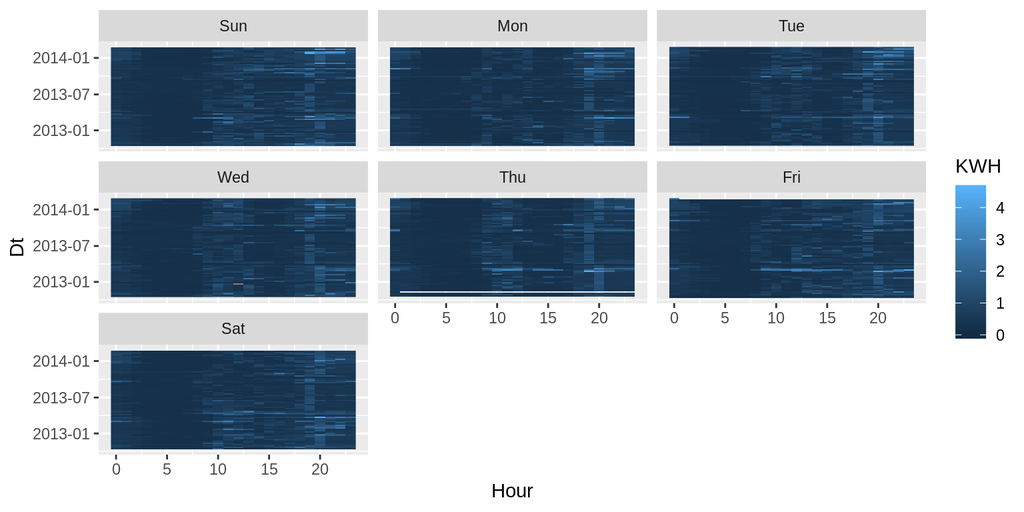

```r
ggplot( dta_bH, aes( x=Hour, y=Dt, fill=KWH ) ) +
  geom_raster() +
  facet_wrap( ~wday )
```

Note the odd shift to the left around March and shift right around October… this is probably related to daylight savings.

# Creative Plotting (3)

Since the original data had no “spring forward” interval in the timestamps (jump of 0.5 hour record interval + 1 hour transition = 1.5 hours, it was probably in standard time year round, so the time instants are right but the clock interpretation needs to be fixed:

```r
dta_p <- dta_b
Sys.setenv( TZ = "Europe/London" ) # default assumption for time zones
# then repeat the timestamp breakdown
d <- as.POSIXlt( dta_p$Dtm ) # keep list time separate from data frame
dta_p$Hour <- d$hour
dta_p$wday <- factor( d$wday, levels = 0:6, labels = c( "Sun", "Mon", "Tue", "Wed", "Thu", "Fri", "Sat" ) )
dta_p$Dt <- as.POSIXct( trunc( d, units="days" ) )
dta_pH <- (   dta_p
          %>% group_by( Dt, Hour, wday )
          %>% summarise( KWH = sum( KWH ) )
          )
head( dta_pH[ as.POSIXct( "2013-03-31" ) == dta_pH$Dt, ] ) # spring forward for London!
```

```
## # A tibble: 6 x 4
## # Groups:   Dt, Hour [6]
##   Dt                   Hour wday    KWH
##   <dttm>              <int> <fct> <dbl>
## 1 2013-03-31 00:00:00     0 Sun   0.2
## 2 2013-03-31 00:00:00     2 Sun   0.218
## 3 2013-03-31 00:00:00     3 Sun   0.213
## 4 2013-03-31 00:00:00     4 Sun   0.219
## 5 2013-03-31 00:00:00     5 Sun   0.208
## 6 2013-03-31 00:00:00     6 Sun   0.232
```

# Creative Plotting (4)

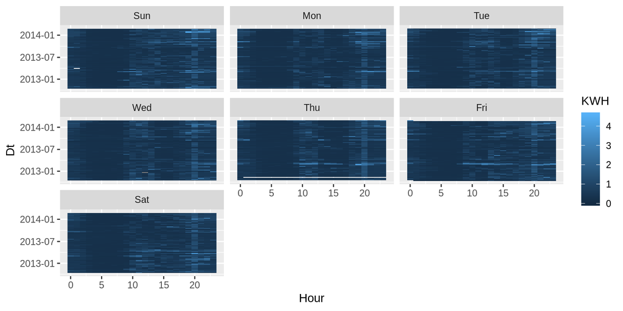

```r
ggplot( dta_pH, aes( x=Hour, y=Dt, fill=KWH ) ) +
  geom_raster() +
  facet_wrap( ~wday )
```

Their peak energy use tends to occur around 8pm on the civil time clock!

# Multi-column Date/Times

An old solar weather file for San Francisco Airport [^2]:

```r
# download.file( url = "https://rredc.nrel.gov/solar/old_data/nsrdb/1961-1990/hourly/1990/23234_90.txt"
#              , destfile = "../data/23234_90.txt"
#              )
dta3 <- read.fwf( "../data/23234_90.txt", header = FALSE
                , skip = 1, stringsAsFactors = FALSE
                , widths = c( 3, 3, 3, 3, 5, 5, 5, 2, 1, 5
                            , 2, 1, 5, 2, 1 )
                , na.strings = " 9999"
                )
dta3 <- setNames( dta3
                , c( "Yr", "Mo", "Dy", "Hr", "G_etdir", "G_etdni"
                   , "G_g", "G_g_src", "G_g_unc", "G_n", "G_n_src"
                   , "G_n_unc", "G_d", "G_d_src", "G_d_unc"
                   )
                )
str( dta3 )
```

```
## 'data.frame':    8760 obs. of  15 variables:
##  $ Yr     : int  90 90 90 90 90 90 90 90 90 90 ...
##  $ Mo     : int  1 1 1 1 1 1 1 1 1 1 ...
##  $ Dy     : int  1 1 1 1 1 1 1 1 1 1 ...
##  $ Hr     : int  1 2 3 4 5 6 7 8 9 10 ...
##  $ G_etdir: int  0 0 0 0 0 0 0 69 246 446 ...
##  $ G_etdni: int  0 0 0 0 0 0 0 731 1415 1415 ...
##  $ G_g    : int  0 0 0 0 0 0 0 7 64 87 ...
##  $ G_g_src: chr  " ?" " ?" " ?" " ?" ...
##  $ G_g_unc: int  0 0 0 0 0 0 0 5 5 4 ...
##  $ G_n    : int  0 0 0 0 0 0 0 0 54 13 ...
##  $ G_n_src: chr  " ?" " ?" " ?" " ?" ...
##  $ G_n_unc: int  0 0 0 0 0 0 0 4 4 4 ...
##  $ G_d    : int  0 0 0 0 0 0 0 7 55 83 ...
##  $ G_d_src: chr  " ?" " ?" " ?" " ?" ...
##  $ G_d_unc: int  0 0 0 0 0 0 0 5 5 5 ...
```

# Multi-column Date/Times

These files were recorded in “local standard time” (no daylight savings). Could set TZ=“GMT” if desired, but here we illustrate what an LST looks like, and show how to convert multiple numeric columns into a timestamp using `ISOdatetime`:

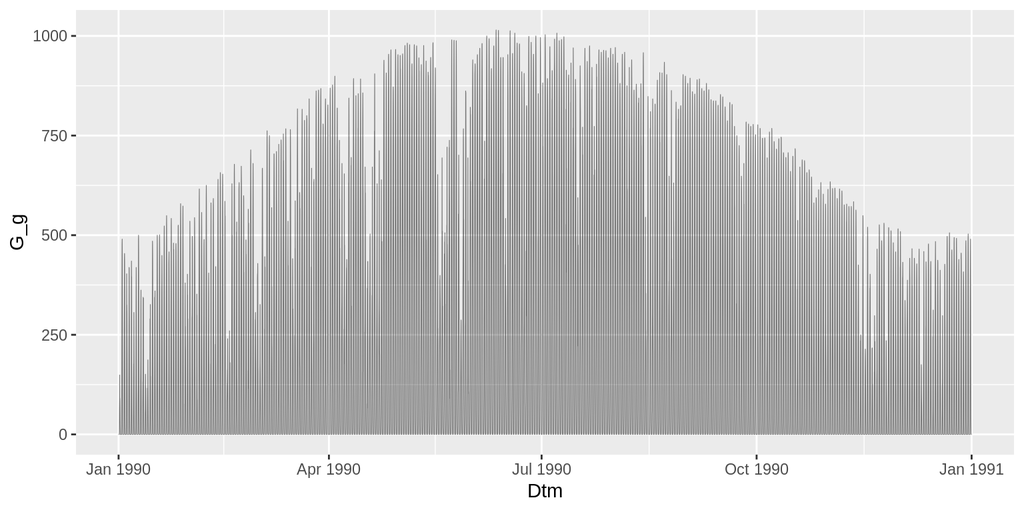

```r
Sys.setenv( TZ = "Etc/GMT+8" ) # yes, that is plus, backwards from current practice
dta3$Dtm <- with( dta3, ISOdatetime( Yr + 1900, Mo, Dy, Hr, 0, 0 ) )
ggplot( dta3, aes( x=Dtm, y=G_g ) ) + geom_line( size=0.2, alpha=0.5 )
```

# Dates and Times

Yet another old source of solar data [^3]:

```r
# download.file( "https://rredc.nrel.gov/solar/old_data/nsrdb/1991-2010/data/hourly/724940/724940_2010_solar.csv"
#              , destfile = "../data/724940_2010_solar.csv"
#              )
dta4 <- read.csv( "../data/724940_2010_solar.csv", check.names = FALSE
                , as.is = TRUE, na.strings = "-9900" )
str( dta4 )
```

```
## 'data.frame':    8760 obs. of  43 variables:
##  $ YYYY-MM-DD               : chr  "2010-01-01" "2010-01-01" "2010-01-01" "2010-01-01" ...
##  $ HH:MM (LST)              : chr  "1:00" "2:00" "3:00" "4:00" ...
##  $ Zenith (deg)             : num  99 99 99 99 99 99 99 87.4 80.1 71.7 ...
##  $ Azimuth (deg)            : num  -99 -99 -99 -99 -99 ...
##  $ ETR (Wh/m^2)             : int  0 0 0 0 0 0 0 36 243 443 ...
##  $ ETRN (Wh/m^2)            : int  0 0 0 0 0 0 0 790 1415 1415 ...
##  $ SUNY Glo (Wh/m^2)        : logi  NA NA NA NA NA NA ...
##  $ SUNY Glo Flg             : int  99 99 99 99 99 99 99 99 99 99 ...
##  $ SUNY Glo Unc (%)         : logi  NA NA NA NA NA NA ...
##  $ SUNY Dir (Wh/m^2)        : logi  NA NA NA NA NA NA ...
##  $ SUNY Dir Flg             : int  99 99 99 99 99 99 99 99 99 99 ...
##  $ SUNY Dir Unc (%)         : logi  NA NA NA NA NA NA ...
##  $ SUNY Dif (Wh/m^2)        : logi  NA NA NA NA NA NA ...
##  $ SUNY Dif Flg             : int  99 99 99 99 99 99 99 99 99 99 ...
```

[output cut: 29 more lines]

# Dates and Times (2)

The `Date` type is convenient if you don’t need to worry about time, but beware of comparing or calculating between `Date` and `POSIXct`:

```r
Sys.setenv(TZ = "Etc/GMT+8" )
dta4$Dt <- as.Date( dta4$`YYYY-MM-DD` )
dta4$Dtm <- as.POSIXct( paste( dta4$`YYYY-MM-DD`, dta4$`HH:MM (LST)` ) )
head( dta4[ , c( "YYYY-MM-DD", "HH:MM (LST)", "Dt", "Dtm" ) ] )
```

```
##   YYYY-MM-DD HH:MM (LST)         Dt                 Dtm
## 1 2010-01-01        1:00 2010-01-01 2010-01-01 01:00:00
## 2 2010-01-01        2:00 2010-01-01 2010-01-01 02:00:00
## 3 2010-01-01        3:00 2010-01-01 2010-01-01 03:00:00
## 4 2010-01-01        4:00 2010-01-01 2010-01-01 04:00:00
## 5 2010-01-01        5:00 2010-01-01 2010-01-01 05:00:00
## 6 2010-01-01        6:00 2010-01-01 2010-01-01 06:00:00
```

```r
dta4$Dtm[ 1 ] - as.POSIXct( dta4$Dt[ 1 ] )
```

```
## Time difference of 9 hours
```

When a `Date` value is converted to `POSIXct`, it is *always* treated as if it was in GMT timezone! If you need a midnight-date that can be compared/subtracted with `POSIXct` intuitively then use `as.POSIXct( trunc( Dtm ) )`. Also avoid mixing variables created with `ISOdate` and `ISOdatetime` for the same reason.

# Date-Time Classes

- `Date`
  - Cannot handle increments of less than one day
  - Internally represented as days since origin date (1970-01-01), a floating point number, fractions ignored
- `POSIXct` (Continuous Time[^5])
  - Very powerful, some people find these intimidating
  - Internally represented as seconds since origin (1970-01-01 00:00:00.000000 GMT), a floating point number, fractions allowed
  - Recommended for general use (set TZ!)
- `POSIXlt` (List Time[^6])
  - Useful for picking apart date/times
  - Internally represented as a list of nine named numeric vectors: sec, min, hour, mday, mon, year, wday, yday, isdst. Should not be used in data frames.

Note that base R does not support working with time-of-day only, since the length of a day can be different in different timezones and/or on different calendar days.

# `Date` (No Time)

```r
Sys.setenv( TZ = "UTC" )
dt1a <- as.Date( "2013-03-13" ) # see ?as.Date
dt1b <- as.Date( "3/21/2013", format="%m/%d/%Y" ) # see ?strptime
dt1b
```

```
## [1] "2013-03-21"
```

```r
as.numeric( dt1b )
```

```
## [1] 15785
```

```r
dt1a < dt1b
```

```
## [1] TRUE
```

```r
dt1b - dt1a
```

```
## Time difference of 8 days
```

# `POSIXct` (Continuous or Compact Time)

Most flexible for computing with instants of time. Can represent precision of smaller than one second, but results may be unreliable due to floating point rounding.

```r
Sys.setenv( TZ = "UTC" )
dtm1 <- as.POSIXct( c( "2016-03-13 01:00:00", "2016-03-13 03:00:00" ) )
dtm1
```

```
## [1] "2016-03-13 01:00:00 UTC" "2016-03-13 03:00:00 UTC"
```

```r
as.numeric( dtm1 )
```

```
## [1] 1457830800 1457838000
```

```r
dtm1[ 1 ] < dtm1[ 2 ]
```

```
## [1] TRUE
```

```r
diff( dtm1 )
```

```
## Time difference of 2 hours
```

# `POSIXlt` (List or Long Time)

```r
Sys.setenv( TZ = "UTC" )
# see ?as.POSIXlt
dtm2 <- as.POSIXlt( c( "2016-03-13 01:00:00", "2016-03-13 03:00:00" ) )
dtm2
```

```
## [1] "2016-03-13 01:00:00 UTC" "2016-03-13 03:00:00 UTC"
```

```r
dtm2[ 1 ] < dtm2[ 2 ]
```

```
## [1] TRUE
```

```r
diff( dtm2 )
```

```
## Time difference of 2 hours
```

# `POSIXlt` Internals

See `?DateTimeClasses`. `year` is based from 1900, `mon` represents January as 0, `wday` starts at 0 for Sunday, `yday` starts at 0 for January 1.

```r
str( unclass( dtm2 ) )
```

```
## List of 9
##  $ sec  : num [1:2] 0 0
##  $ min  : int [1:2] 0 0
##  $ hour : int [1:2] 1 3
##  $ mday : int [1:2] 13 13
##  $ mon  : int [1:2] 2 2
##  $ year : int [1:2] 116 116
##  $ wday : int [1:2] 0 0
##  $ yday : int [1:2] 72 72
##  $ isdst: int [1:2] 0 0
##  - attr(*, "tzone")= chr "UTC"
```

```r
dtm2$year + 1900
```

```
## [1] 2016 2016
```

# `difftime` for Durations

The amount of time between two points in time is treated differently than the points in time themselves. You cannot add two `POSIXct` values, but you can add a `POSIXct` with as many `difftime` values as desired.

```r
diftm1 <- as.difftime( 30, units="mins" ) # see ?as.difftime
dtm1[ 1 ] + diftm1
```

```
## [1] "2016-03-13 01:30:00 UTC"
```

```r
dtm1[ 1 ] + as.difftime( 2, units="weeks" )
```

```
## [1] "2016-03-27 01:00:00 UTC"
```

# `difftime` Numeric Equivalent

If you need to know the value of a difftime you must remember to specify the units or you may get whatever “convenient” units R wants to use:

```r
as.numeric( diftm1 ) # not recommended
```

```
## [1] 30
```

```r
as.numeric( diftm1, units="mins" )
```

```
## [1] 30
```

```r
as.numeric( diftm1, units="secs" )
```

```
## [1] 1800
```

# Timezones (1)

Time zones are identified using string labels that are technically OS-dependent, but for Windows/Mac/Linux the Olson database is used so this is fairly widely applicable [^7].

```r
on <- OlsonNames()
tail( on ) # a few examples
```

```
## [1] "US/Pacific-New" "US/Samoa"       "UTC"            "W-SU"
## [5] "WET"            "Zulu"
```

```r
grep( "Los_Angeles", on, value=TRUE )
```

```
## [1] "America/Los_Angeles"
```

Note that even though sometimes R will use a 3-letter timezone abbreviation, such shorthand is usually not acceptable for *specifying* the timezone.

# Timezones (2)

No matter what timezone you use, the underlying numeric value of a `POSIXct` will be assumed to count from the origin instant in GMT.

If you don’t have any reason to be concerned with timezones in your data, you can make life “easy” for yourself by setting your working timezone to be “GMT” or “UTC”.

Converting `Date` to `POSIXct` *always* treats the date as beginning of the day in GMT, so if you use any other timezone for other values then you will want to “force” the timezone to be compatible with any other `POSIXct` values you may be working with.

Note that each vector of `POSIXct` can have its own timezone, but some functions can cause that timezone to get lost, or will create time values internally using the default (TZ) timezone, so it is simplest to change the TZ as needed while doing input, then use some single timezone of your choosing while doing calculations and generating output.

# `lubridate` package (1)

The `lubridate`[^8] package provides many “helper” functions for working with `POSIXct` and `Date` values.

```r
library(lubridate)
mdy( "3/14/2013" ) == as.Date( "3/14/2013", format="%m/%d/%Y" )
```

```
## [1] TRUE
```

```r
dmy_hms( "14/3/13 1:15:45" ) == as.POSIXct( "14/3/13 1:15:45", format = "%d/%m/%y %H:%M:%S")
```

```
## [1] TRUE
```

# `lubridate` package (2)

You can repair a time value that was converted to POSIXct with the wrong timezone:

```r
dtm1[ 1 ]
```

```
## [1] "2016-03-13 01:00:00 UTC"
```

```r
force_tz( dtm1, "US/Pacific" ) # this is a different point in time
```

```
## [1] "2016-03-13 01:00:00 PST" "2016-03-13 03:00:00 PDT"
```

Or you can display a given instant of time using a different timezone:

```r
with_tz( dtm1, "US/Pacific" )
```

```
## [1] "2016-03-12 17:00:00 PST" "2016-03-12 19:00:00 PST"
```

```r
# which is easier to remember than
# attr( dtm1, "tzone" ) <- "US/Pacific"
```

# `lubridate` package (3)

Three additional ways beyond `difftime` to represent time intervals are also provided:

```r
interval( dtm1[ 1 ], dtm1[ 2 ] ) # a very specific interval of time
```

```
## [1] 2016-03-13 01:00:00 UTC--2016-03-13 03:00:00 UTC
```

```r
dtm1PT <- force_tz( dtm1[ 1 ], "US/Pacific" )
dtm1PT + days( 1 ) # add a 1 day period (acts like a calendar)
```

```
## [1] "2016-03-14 01:00:00 PDT"
```

```r
dtm1PT + ddays( 1 ) # add a 1 day duration (much like difftime(1,units="days"))
```

```
## [1] "2016-03-14 02:00:00 PDT"
```

There exists a cheat sheet summary of `lubridate` functions.[^9]

# Conclusion

- Best to use `Date` and `POSIXct`
- Always set `TZ` before using time functions!
  - If you don’t know the correct timezone, you can often get along by just pretending it is in “GMT”.
  - The available list of timezones can be obtained using the `OlsonNames()` function
- `lubridate` is convenient for working with times, but less efficient than using `POSIXlt` directly
- Avoid converting `POSIXct` directly to numeric… it is unnecessary in most cases and makes your time manipulations overly-complicated
  - It is fine to convert `difftime` to and from numeric… just remember to specify the units in both conversion directions
- Use `sum( is.na( Dtm ) )` to check if invalid date/times were present. These may indicate incorrect timezone assumptions (including failure to set `TZ`) if they occur in the daylight-savings-time spring-forward hour.
[^1]: https://data.london.gov.uk/dataset/smartmeter-energy-use-data-in-london-households
[^2]: *NSRDB 1961-1990: Hourly Data Files*, https://rredc.nrel.gov/solar/old_data/nsrdb/1961-1990/
[^3]: *National Solar Radiation Data Base 1991- 2010 Update*, https://rredc.nrel.gov/solar/old_data/nsrdb/1991-2010/
[^4]: G. Grothendieck and T. Petzoldt, “R Help Desk: Date and Time Classes in R,” R News, vol. 4, no. 1, pp. 29–32, Jun-2004 [Online]. Available: https://www.r-project.org/doc/Rnews/Rnews_2004-1.pdf.
[^5]: M. J. Crawley, *Statistics: an introduction using R*, 1st ed. Chichester, West Sussex, England: J. Wiley, 2005.
[^6]: M. J. Crawley, *Statistics: an introduction using R*, 1st ed. Chichester, West Sussex, England: J. Wiley, 2005.
[^7]: https://en.wikipedia.org/wiki/List_of_tz_database_time_zones
[^8]: G. Grolemund and H. Wickham, “Dates and Times Made Easy with lubridate,” Journal of Statistical Software, vol. 40, no. 3, pp. 1–25, 2011 [Online]. Available: http://www.jstatsoft.org/v40/i03/
[^9]: “Dates and times with lubridate :: CHEAT SHEET.” RStudio, Dec-2017 [Online]. Available: https://github.com/rstudio/cheatsheets/raw/master/lubridate.pdf